# Multilevel modeling with R

Pablo Barbera

The following code is based on materials generously shared by by Zoltan Fazekas.

```r
library(ggplot2)
library(lme4)
library(arm)
options(stringsAsFactors = FALSE)
```

### Multilevel modeling

Our running example to learn about multilevel models using R will be a study of the relationship between having a college and support for Trump in the 2016 ANES (American National Election Study).

```r
anes <- read.csv("../data/anes-ml.csv", stringsAsFactors=FALSE)
```

This dataset contains observations in all 50 states (plus DC), and thus has a hierarchical structure, with level 1 observations (individuals) nested within level-2 units (states). It has three variables: `trump` (Trump feeling thermometer, from 0 to 100, where highest is more support), `college` (dummy variable indicating whether respondent has a college degree), and `state` (a character string that indicates the U.S. state where the respondent leaves).

```r
nrow(anes)
```

```
## [1] 4271
```

```r
summary(anes)
```

```
##      trump           college         state
##  Min.   :  0.00   Min.   :0.000   Length:4271
##  1st Qu.:  0.00   1st Qu.:0.000   Class :character
##  Median : 30.00   Median :1.000   Mode  :character
##  Mean   : 36.95   Mean   :0.529
##  3rd Qu.: 70.00   3rd Qu.:1.000
##  Max.   :100.00   Max.   :1.000
##  NA's   :41       NA's   :44
```

```r
table(anes$state)
```

```
##
##  AK  AL  AR  AZ  CA  CO  CT  DC  DE  FL  GA  HI  IA  ID  IL  IN  KS  KY
##   4  44  52  97 414  98  59  28  11 217 118  10  36  58 196  94  94  59
##  LA  MA  MD  ME  MI  MN  MO  MS  MT  NC  ND  NE  NH  NJ  NM  NV  NY  OH
##  63 113  97  11 138  82  61  57  11 172   7  24  38 109  41  32 177 162
##  OK  OR  PA  RI  SC  SD  TN  TX  UT  VA  VT  WA  WI  WV  WY
##  66  44 174  10  60  10 150 329  26  87   9  95  97  20  10
```

When thinking about how having a college degree may affect evaluations of Trump, it is not unreasonable to think that different states will have different baseline levels of support for Trump (regardless of education) and also that the effect of a college degree may vary across states. Thus, in this case it may be appropriate to have a varying intercepts and varying slopes model.

### Models with no predictors

But for now let’s start with the simplest model: a **complete pooling** model that ignores the hierarchical structure of the data and only has one intercept. Here, we find that the average thermometer response is 36.9 (95% CI from 35.9 to 38.0)

```r
pool <- glm(trump ~ 1, data=anes)
summary(pool)
```

```
##
## Call:
## glm(formula = trump ~ 1, data = anes)
##
## Deviance Residuals:
##     Min       1Q   Median       3Q      Max
## -36.952  -36.952   -6.952   33.048   63.048
##
## Coefficients:
##             Estimate Std. Error t value Pr(>|t|)
## (Intercept)  36.9522     0.5367   68.84   <2e-16 ***
## ---
## Signif. codes:  0 '***' 0.001 '**' 0.01 '*' 0.05 '.' 0.1 ' ' 1
##
## (Dispersion parameter for gaussian family taken to be 1218.646)
##
##     Null deviance: 5153654  on 4229  degrees of freedom
## Residual deviance: 5153654  on 4229  degrees of freedom
##   (41 observations deleted due to missingness)
## AIC: 42063
##
## Number of Fisher Scoring iterations: 2
```

```r
confint(pool)
```

```
##    2.5 %   97.5 %
## 35.90024 38.00425
```

Of course, we know this model is too simple. This estimate fails to capture the large differences in the feeling thermometer we should observe across the U.S. A better estimate of the level of support for Trump in each state is to just take the state average. This could be achieved using a **no pooling** model where we include a fixed effect for each state.

(Note we add `-1` so that the intercept is dropped and we get a different fixed effect for each state.)

Here we see that there are indeed large differences in the averages across states. However, one limitation of these estimates is that the highest and lowest are likely to be over- and under-estimating the true average. Why? Given the small sample size in some states, it is likely we have estimated those extreme values just by chance alone.

```r
no.pool <- glm(trump ~ state - 1, data=anes)
no.pool
```

```
##
## Call:  glm(formula = trump ~ state - 1, data = anes)
##
## Coefficients:
## stateAK  stateAL  stateAR  stateAZ  stateCA  stateCO  stateCT  stateDC
##   46.67    55.67    53.35    41.93    28.07    30.39    31.25     8.50
## stateDE  stateFL  stateGA  stateHI  stateIA  stateID  stateIL  stateIN
##   23.80    36.42    43.47    32.30    40.92    39.71    31.46    47.54
## stateKS  stateKY  stateLA  stateMA  stateMD  stateME  stateMI  stateMN
##   40.14    50.14    53.51    28.76    35.42    61.09    35.74    34.59
## stateMO  stateMS  stateMT  stateNC  stateND  stateNE  stateNH  stateNJ
##   46.51    39.82    55.36    35.77    55.43    33.17    25.53    32.86
## stateNM  stateNV  stateNY  stateOH  stateOK  stateOR  statePA  stateRI
##   39.32    27.71    31.64    39.84    40.74    25.09    37.78    36.80
## stateSC  stateSD  stateTN  stateTX  stateUT  stateVA  stateVT  stateWA
##   34.47    53.10    48.56    38.13    32.00    40.45    14.67    35.12
## stateWI  stateWV  stateWY
##   37.84    54.42    56.60
##
## Degrees of Freedom: 4230 Total (i.e. Null);  4179 Residual
##   (41 observations deleted due to missingness)
## Null Deviance:       10930000
## Residual Deviance: 4918000   AIC: 41970
```

```r
# saving no pooling estimates for later
np_est <- data.frame(
  state = gsub("state", "", names(coef(no.pool))),
  coef = coef(no.pool),
  se = diag(sqrt(vcov(no.pool))),
  model = "No pooling"
)
```

In these cases, a better approach is to have a model where we do **partial pooling**, in order to “borrow strength” from groups with more observations and thus shrink some of the extreme estimates towards the grand mean. We can achieve this using a **varying-intercept model with no predictors**:

```r
mlm.0 <- lmer(trump ~ 1 + (1 | state),
              data = anes)
mlm.0
```

```
## Linear mixed model fit by REML ['lmerMod']
## Formula: trump ~ 1 + (1 | state)
##    Data: anes
## REML criterion at convergence: 41983.29
## Random effects:
##  Groups   Name        Std.Dev.
##  state    (Intercept)  7.317
##  Residual             34.331
## Number of obs: 4230, groups:  state, 51
## Fixed Effects:
## (Intercept)
##       38.17
```

```r
coef(mlm.0)
```

```
## $state
##    (Intercept)
## AK    39.18555
## AL    49.74625
## AR    48.77423
## AZ    41.22554
## CA    28.58108
## CO    31.81443
## CT    33.13228
## DC    21.55720
## DE    33.67837
## FL    36.58158
## GA    42.63018
## HI    36.33358
## IA    39.87293
## ID    39.28297
## IL    32.14095
## IN    45.76342
## KS    39.75993
## KY    46.80434
## LA    49.53540
## MA    30.30411
## MD    35.93008
## ME    45.80472
## MI    36.07973
## MN    35.37687
## MO    44.29608
## MS    39.35432
## MT    43.89635
## NC    36.04496
## ND    42.33101
## NE    35.61519
## NH    30.16253
## NJ    33.75928
## NM    38.91496
## NV    32.05148
## NY    32.37614
## OH    39.63734
## OK    40.08767
## OR    29.45092
## PA    37.82297
## RI    37.73928
## SC    35.47760
## SD    42.83103
## TN    47.22537
## TX    38.13693
## UT    34.82695
## VA    39.97784
## VT    31.34636
## WA    35.68960
## WI    37.89626
## WV    45.69651
## WY    43.92435
##
## attr(,"class")
## [1] "coef.mer"
```

```r
# saving varying intercept model estimates
vi_est <- data.frame(
  state = rownames(coef(mlm.0)$state),
  coef = coef(mlm.0)$state[,1],
  se = se.ranef(mlm.0)$state[,1],
  model = "Varying intercepts"
)
```

We can now compare the two sets of estimates to see this shrinking in the partial pooling model taking place. Note also how some the largest confidence intervals in the no pooling model also become much smaller, since we now borrow strength from other states (and have more certainty about how some of the extreme values are actually less likely).

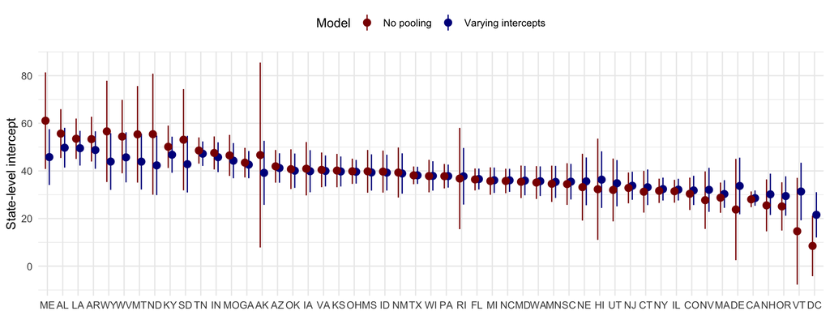

```r
## comparative plot
ggplot(rbind(np_est, vi_est),
       aes(x      = reorder(state, -coef),
           y      = coef,
           ymin   = coef - 1.96 * se,
           ymax   = coef + 1.96 * se,
           color = model)) +
  geom_pointrange(position = position_dodge(width=0.5)) +
  scale_color_manual("Model", values = c("darkred",
                                    "darkblue")) +
  ylab("State-level intercept") + xlab("") +
  theme(axis.text.x = element_text(angle = 90)) +
  theme_minimal() +
  theme(legend.position = "top")
```

### Models with predictors

Now let’s switch to a slightly different estimation problem: let’s say we want to know whether respondents with a college degree are more or less likely to express warm feelings towards Trump.

As earlier, we can start with a **complete pooling** model: respondents with a college degree give responses that are 6.3 points less warm in average.

```r
pool <- glm(trump ~ college, data=anes)
summary(pool)
```

```
##
## Call:
## glm(formula = trump ~ college, data = anes)
##
## Deviance Residuals:
##     Min       1Q   Median       3Q      Max
## -40.327  -34.016   -4.016   29.673   65.984
##
## Coefficients:
##             Estimate Std. Error t value Pr(>|t|)
## (Intercept)   40.327      0.784  51.435  < 2e-16 ***
## college       -6.311      1.076  -5.866 4.81e-09 ***
## ---
## Signif. codes:  0 '***' 0.001 '**' 0.01 '*' 0.05 '.' 0.1 ' ' 1
##
## (Dispersion parameter for gaussian family taken to be 1207.293)
##
##     Null deviance: 5095272  on 4187  degrees of freedom
## Residual deviance: 5053731  on 4186  degrees of freedom
##   (83 observations deleted due to missingness)
## AIC: 41608
##
## Number of Fisher Scoring iterations: 2
```

This model assumes that the average response for all individuals without a college degree (i.e. the intercept) is the same for all states – something we now know is likely unreasonable. Thus we can estimate a multilevel model with **varying intercepts**. We now find a smaller estimate of the effect: -5.6 points.

```r
## varying intercept with 1 predictor (college)
mlm.1 <- lmer(trump ~ college +
                (1 | state),
              data = anes)
summary(mlm.1)
```

```
## Linear mixed model fit by REML ['lmerMod']
## Formula: trump ~ college + (1 | state)
##    Data: anes
##
## REML criterion at convergence: 41533
##
## Scaled residuals:
##     Min      1Q  Median      3Q     Max
## -1.5080 -0.9389 -0.1247  0.8467  2.1579
##
## Random effects:
##  Groups   Name        Variance Std.Dev.
##  state    (Intercept)   46.24   6.80
##  Residual             1171.22  34.22
## Number of obs: 4188, groups:  state, 51
##
## Fixed effects:
##             Estimate Std. Error t value
## (Intercept)   41.087      1.316  31.226
## college       -5.576      1.068  -5.219
##
## Correlation of Fixed Effects:
##         (Intr)
## college -0.428
```

Finally, we can relax even further our assumptions and test whether the effect of a college degree varies across states as well. To answer this question, we can fit a **varying intercepts, varying slope** model. As you can see below, we now have a separate intercept and a separate estimate for the effect of a college degree in each state.

```r
## varying intercept + varying slope model
mlm.2 <- lmer(trump ~ college + (1 + college | state),
              data = anes)
summary(mlm.2)
```

```
## Linear mixed model fit by REML ['lmerMod']
## Formula: trump ~ college + (1 + college | state)
##    Data: anes
##
## REML criterion at convergence: 41532.6
##
## Scaled residuals:
##     Min      1Q  Median      3Q     Max
## -1.5337 -0.9455 -0.1188  0.8513  2.1460
##
## Random effects:
##  Groups   Name        Variance Std.Dev. Corr
##  state    (Intercept)   52.333  7.234
##           college        1.542  1.242   -0.71
##  Residual             1170.915 34.219
## Number of obs: 4188, groups:  state, 51
##
## Fixed effects:
##             Estimate Std. Error t value
## (Intercept)   41.211      1.372   30.03
## college       -5.770      1.091   -5.29
##
## Correlation of Fixed Effects:
##         (Intr)
## college -0.511
```

```r
coef(mlm.2)
```

```
## $state
##    (Intercept)   college
## AK    42.26323 -5.921799
## AL    50.99219 -6.838705
## AR    51.93459 -6.898897
## AZ    44.43999 -6.185422
## CA    31.19065 -4.625102
## CO    34.46443 -4.933349
## CT    36.34864 -5.217469
## DC    25.90375 -4.172237
## DE    36.43560 -5.182817
## FL    38.79382 -5.110991
## GA    46.13010 -6.344005
## HI    39.70619 -5.564842
## IA    43.76929 -6.237268
## ID    42.84844 -6.069263
## IL    34.76013 -4.945805
## IN    47.77208 -6.447559
## KS    42.58957 -5.838352
## KY    49.76427 -6.776403
## LA    52.48137 -7.122111
## MA    33.98800 -5.211323
## MD    39.20596 -5.532810
## ME    48.44319 -6.699567
## MI    39.03818 -5.432622
## MN    38.64117 -5.466220
## MO    47.66859 -6.550832
## MS    41.05095 -5.733125
## MT    46.59201 -6.347910
## NC    38.84797 -5.365341
## ND    44.72044 -6.182679
## NE    38.94028 -5.488422
## NH    34.34794 -5.049263
## NJ    37.29075 -5.305782
## NM    42.29796 -5.869500
## NV    35.30128 -5.111384
## NY    35.28278 -5.117097
## OH    43.07073 -6.076516
## OK    42.73448 -5.941633
## OR    33.05059 -4.959698
## PA    41.02930 -5.756632
## RI    40.94717 -5.714099
## SC    38.44516 -5.444224
## SD    45.84472 -6.297579
## TN    50.71478 -6.988351
## TX    40.87050 -5.379577
## UT    37.77105 -5.396661
## VA    43.58899 -6.081083
## VT    34.57437 -5.020241
## WA    38.40001 -5.461136
## WI    41.31315 -5.776331
## WV    48.29793 -6.609992
## WY    46.84422 -6.469088
##
## attr(,"class")
## [1] "coef.mer"
```

We find large variation in the effect of a college degree, for example from -4.6 points in California to 6.9 points in Arkansas. If we plot these two sets of estimates, we find that these are actually highly correlated: the effect of a college degree is largest in states where the baseline support for Trump is highest. There are different ways we could interpret this finding: perhaps it’s just a floor effect (in some states the average was low, and thus there wasn’t a lot of room for change) or there might be a more substantive interpretation, such as the fact that education is correlated with socioeconomic status and race/ethnicity, and thus here we could be capturing the size of the gap along these dimensions on support for Trump.

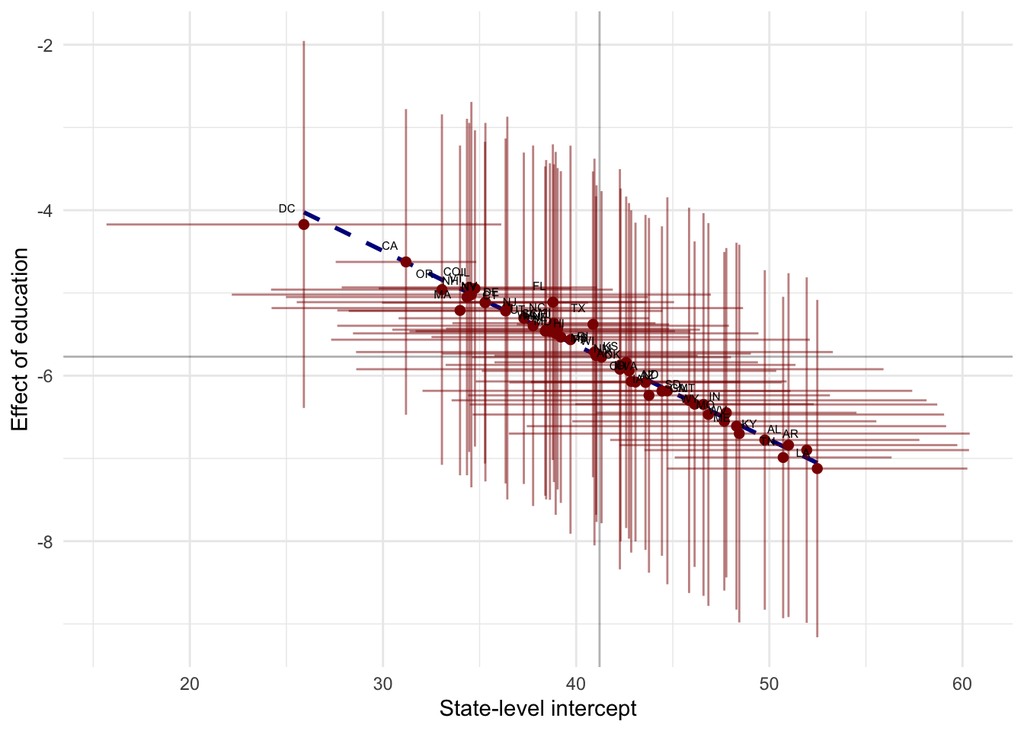

```r
h_res <- as.data.frame(coef(mlm.2)$state[1:2])
se    <- data.frame(se.ranef(mlm.2)$state)
h_res <- cbind(h_res, se)
names(h_res)[1:4] <- c("alpha", "beta", "alpha_se", "beta_se")
h_res$state <- rownames(h_res)

ggplot(h_res,
       aes(x     = alpha,
           y     = beta,
           label = state,
           ymin  = beta - 2 * beta_se,
           ymax  = beta + 2 * beta_se)) +
  geom_vline(xintercept = fixef(mlm.2)[1], alpha = 0.3) + ## grand-mean
  geom_hline(yintercept = fixef(mlm.2)[2], alpha = 0.3) + ## grand-mean know.
  stat_smooth(method = "lm",
              linetype = 2,
              colour = "darkblue",
              se = FALSE) + ## the "correlation"
  geom_linerange(alpha = 0.5, colour = "darkred") + ## uncertainty beta
  geom_errorbarh(aes(xmax = alpha + 2*alpha_se,     ## uncertainty alpha
                     xmin = alpha - 2*alpha_se, height = 0),
                 alpha = 0.5, colour = "darkred") +
  geom_point(shape = 20, size = 3, colour = "darkred") +
  geom_text(size = 2, hjust = 1.5, vjust = -1.5) +
  ylab("Effect of education") +
  xlab("State-level intercept") +
  theme_minimal()
```